# game24 Package

# 4) game24prob

This function helps user to get information on the probability of combinations of a card that is being able to get 24. The probability was calculated from game24table.

```r
game24prob(7,24)
```

```
## [1] 0.6958042
```

```r
game24prob(4,24)
```

```
## [1] 0.8741259
```

# 5) plot_comparison

This function gives user a comparison barplot of the probability of each cards getting 24 vs getting other number instead of 24. y axis is the probability to get 24 or other number for each combination containing the specific cards. We know that some of the combinations are not being able to get 24 or other number, so we make the comparison plot.

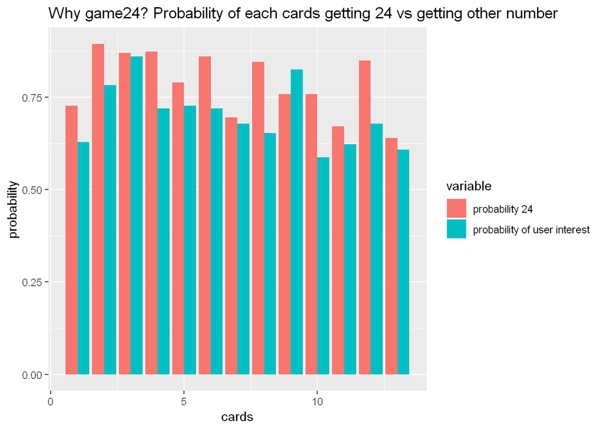

```r
plot_comparison(27)
```

# 6) game24_makeCards

This function allows user to play the famous card game 24 on the console. It gives the user four random cards between 1-13 and allows the user to input when they would like to see solutions.

```r
game24_makeCards()
```

# 7) gameKrypto_makeCards

This function allows user to play the famous card game Krypto on the console. It gives the user four random cards along with a fifth random objective card between 1-13 and allows the user to input when they would like to see solutions.

```r
gameKrypto_makeCards()
```

# 8) game_check

This function can help you to check whether a series of number can generate another number that user input. For example, we want to know if 3,4,5,6 can generate 47 by basic operations.

```r
game_check(c(3,4,5,6),b=47)
```

```
## [1] "This is at least one way to get 47"
```